# Stat 480 - Homework #2

Jeremy Miranda

1/30/2020

## Economic Guide to Picking a College Major

1. Download the RMarkdown file with these homework instructions to use as a template for your work. Make sure to replace “Your Name” in the YAML with your name.
2. Using the command below, read in the data set into your R session.

```r
recent_grads <- read.csv("https://raw.githubusercontent.com/Stat480-at-ISU/materials-2020/master/02-r_intro/data/recent_grads.csv")
```

```r
library(dplyr)
```

3. Create a new variable, `share_women`, in the dataset that is women as share of total; i.e. the number of women divided by the total number of men and women.

```r
women = sum(recent_grads$Women,na.rm = TRUE)
men = sum(recent_grads$Men,na.rm = TRUE)
share_women = ((women)/(women + men))
```

4. Create a subset of the data containing only the rows where the `Major_category` is `STEM`.

```r
stem <- recent_grads %>% filter(Major_category == "STEM")
```

5. For your subset, compute the average of `share_women` and its standard deviation. Also compute the mean median earnings (`Median`) and its standard deviation. Comment on the results. (You might have to deal with missing values appropriately).

```r
women2 = sum(stem$Women,na.rm = TRUE)
men2 = sum(stem$Men,na.rm = TRUE)
share_women2 = ((women2)/(women2 + men2))
sd(share_women2)
```

```
## [1] NA
```

```r
#Smaller percentage of women have a stem degree compared to the total

average = sum(stem$Median,na.rm = TRUE)/length(stem$Major)
sd(stem$Median)
```

```
## [1] 12765.18
```

6. Again using the subset, compute the correlation between women as a share of total (`share_women`) and the median earnings (`Median`) and interpret your results.

```r
stem$Women
```

[output not shown]

```r
stem$Men
```

[output not shown]

```r
share_women2 = ((stem$Women)/(stem$Women + stem$Men))
cor(stem$Median,share_women2, use = "complete.obs")
```

```
## [1] -0.6125043
```

```r
#Salary and percentage of women are negatively correlated. The more women the lower the pay.
```

7. Use the original dataset and `ggplot2` to draw a scatterplot of women as share of total and the median earnings. Color points by the major category (`Major_category`). Comment on the result.

```r
library(ggplot2)
recent_grads$Women
```

[output not shown]

```r
recent_grads$Men
```

[output not shown]

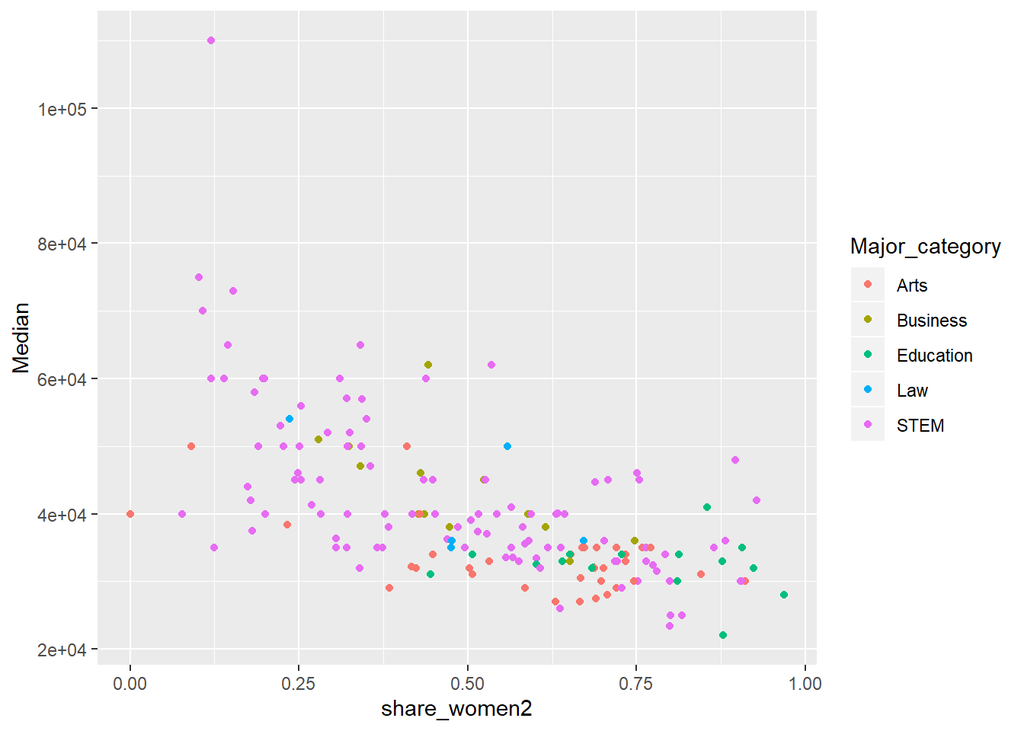

```r
share_women2 = ((recent_grads$Women)/(recent_grads$Women + recent_grads$Men))
ggplot(data = recent_grads, aes(x = share_women2, y = Median)) +
  geom_point(aes(color = Major_category))
```

```r
#strength: moderately strong
#direction: decreasing
#outliers: yes there is one distinct outlier
#relationship: negative
```

**Due date**: the homework is due before class on Thursday.

**For the submission**: submit your solution in an R Markdown file and (just for insurance) submit the corresponding html file with it.